# Reproducible Research: Peer Assessment 1

## Loading and preprocessing the data

Show any code that is needed to:

- Load the data (i.e. read.csv())
- Process/transform the data (if necessary) into a format suitable for your analysis
  - Processing for each step is included in the appropriate step

```r
library(dplyr)
data<-read.csv("activity.csv")
```

## What is mean total number of steps taken per day?

For this part of the assignment, you can ignore the missing values in the dataset.

- Calculate the total number of steps taken per day
  - Table of data listed below
- Make a histogram of the total number of steps taken each day
- Calculate and report the mean and median of the total number of steps taken per day

```r
by_day<-data %>%
  filter (steps != "NA") %>%
  group_by(date) %>%
  summarise_each(funs(sum), steps)
by_day
```

```
## Source: local data frame [53 x 2]
##
##          date steps
## 1  2012-10-02   126
## 2  2012-10-03 11352
## 3  2012-10-04 12116
## 4  2012-10-05 13294
## 5  2012-10-06 15420
## 6  2012-10-07 11015
## 7  2012-10-09 12811
## 8  2012-10-10  9900
## 9  2012-10-11 10304
## 10 2012-10-12 17382
## 11 2012-10-13 12426
## 12 2012-10-14 15098
```

[output cut: 41 more lines]

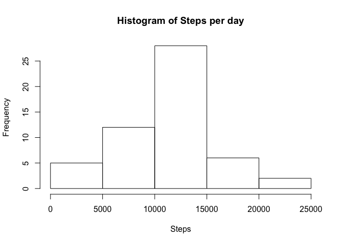

```r
hist(by_day$steps, xlab="Steps", main="Histogram of Steps per day")
```

```r
mean(by_day$steps)
```

```
## [1] 10766.19
```

```r
median(by_day$steps)
```

```
## [1] 10765
```

## What is the average daily activity pattern?

- Make a time series plot (i.e. type = “l”) of the 5-minute interval (x-axis) and the average number of steps taken, averaged across all days (y-axis)
- Which 5-minute interval, on average across all the days in the dataset, contains the maximum number of steps?
  - Computed below

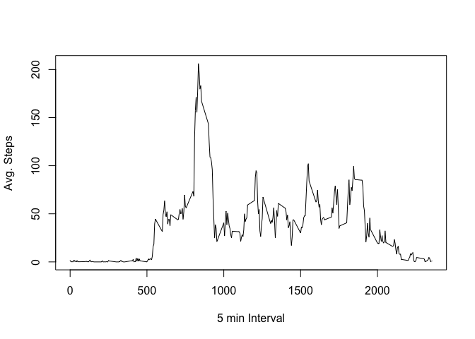

```r
by_interval<-data %>%
  filter (steps != "NA") %>%
  group_by(interval) %>%
  summarise_each(funs(mean), steps)
plot(by_interval$interval, by_interval$steps, type = "l", xlab="5 min Interval", ylab="Avg. Steps")
```

```r
filter(by_interval, steps==max(steps))
```

```
## Source: local data frame [1 x 2]
##
##   interval    steps
## 1      835 206.1698
```

## Imputing missing values

Note that there are a number of days/intervals where there are missing values (coded as NA). The presence of missing days may introduce bias into some calculations or summaries of the data.

```r
sum(is.na(data))
```

```
## [1] 2304
```

```r
colnames(by_interval)<-c("interval", "avg_steps")
newdata<-merge(data, by_interval, by="interval") %>%
  select(steps, date, interval, avg_steps)
for(i in 1:length(newdata$steps)){
  if(is.na(newdata$steps[i])){
    newdata$steps[i]<-newdata$avg_steps[i]
  }
}

new_by_day<-newdata %>%
  group_by(date) %>%
  summarise_each(funs(sum), steps)
new_by_day
```

```
## Source: local data frame [61 x 2]
##
##          date    steps
## 1  2012-10-01 10766.19
## 2  2012-10-02   126.00
## 3  2012-10-03 11352.00
## 4  2012-10-04 12116.00
## 5  2012-10-05 13294.00
## 6  2012-10-06 15420.00
## 7  2012-10-07 11015.00
## 8  2012-10-08 10766.19
## 9  2012-10-09 12811.00
## 10 2012-10-10  9900.00
## 11 2012-10-11 10304.00
## 12 2012-10-12 17382.00
```

[output cut: 49 more lines]

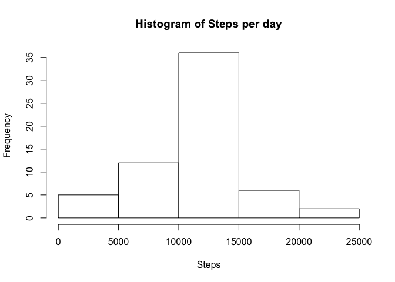

```r
hist(new_by_day$steps, xlab="Steps", main="Histogram of Steps per day")
```

```r
mean(new_by_day$steps)
```

```
## [1] 10766.19
```

```r
median(new_by_day$steps)
```

```
## [1] 10766.19
```

## Are there differences in activity patterns between weekdays and weekends?

For this part the weekdays() function may be of some help here. Use the dataset with the filled-in missing values for this part.

- Create a new factor variable in the dataset with two levels – “weekday” and “weekend” indicating whether a given date is a weekday or weekend day.
- Make a panel plot containing a time series plot (i.e. type = “l”) of the 5-minute interval (x-axis) and the average number of steps taken, averaged across all weekday days or weekend days (y-axis). See the README file in the GitHub repository to see an example of what this plot should look like using simulated data.

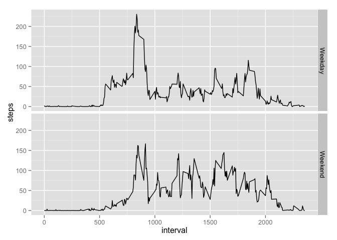

```r
for(i in 1:length(newdata$steps)){
  if((weekdays(as.Date(newdata$date[i])) == "Saturday") | (weekdays(as.Date(newdata$date[i])) == "Sunday")) {
    newdata$weekend[i]<-"Weekend"
    }
  else {
    newdata$weekend[i]<-"Weekday"
  }
}
newdata$weekend <- as.factor(newdata$weekend)
by_interval_by_weekend<-newdata %>%
  group_by(weekend) %>%
  group_by(interval, add=TRUE) %>%
  summarise_each(funs(mean), steps)

library(ggplot2)
ggplot(by_interval_by_weekend, aes(interval,steps)) + geom_line() + facet_grid(weekend ~ .)
```